# Section 5.3 R Example

To illustrate the ideas in this chapter, we will predict **house prices** from a set of features including `size`, `beds`, `zip`, and a `wealth index`. This is a simulated example for illustration purposes, and the data can be found and downloaded in Section 5.3.

The response $y$ (house price) is obviously continuous, so we will fit linear and nonlinear regression models, this is the specified $\phi$ from the previous chapters, and then we will employ a neural net to *learn* $\phi_c$ using a squared error loss. In the end we will compare the results on the testing set.

We will report $\frac1n\sum_i(\hat y_i-y_i)^2$ on a test set.

```r
library(tidyverse)
library(nnet)
set.seed(598)

relu <- function(z) pmax(z, 0)
mse  <- function(y, yhat) mean((y - yhat)^2)
```

```r
houses <- read.csv("houses.csv", header = TRUE) %>%
  mutate(zip = factor(zip))
```

`zip` must be a factor which means that it will enter the regression as a et of dummy variables.

## Scatter Plots

We start by investigating the pairwise relationship of the response vs. `size` and `wealth` grouped by zip code.

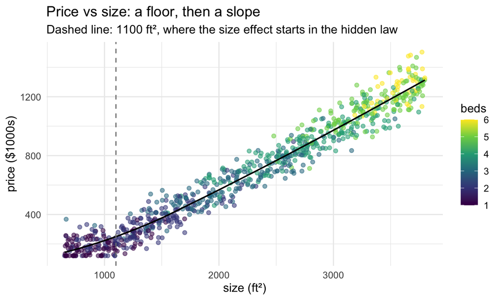

```r
houses %>%
  ggplot(aes(size, price, colour = beds)) +
  geom_point(alpha = 0.55, size = 1.6) +
  geom_smooth(method = "loess", se = FALSE, colour = "black", linewidth = 0.7) +
  geom_vline(xintercept = 1100, linetype = 2, colour = "grey50") +
  scale_colour_viridis_c() +
  labs(
    title = "Price vs size: a floor, then a slope",
    subtitle = "Dashed line: 1100 ft², where the size effect starts in the hidden law",
    x = "size (ft²)", y = "price ($1000s)",
    colour = "beds"
  ) +
  theme_minimal(base_size = 12)
```

We can see that the straight line does not have a very good fit. There is a corner/elbow on the lower left of the plot.

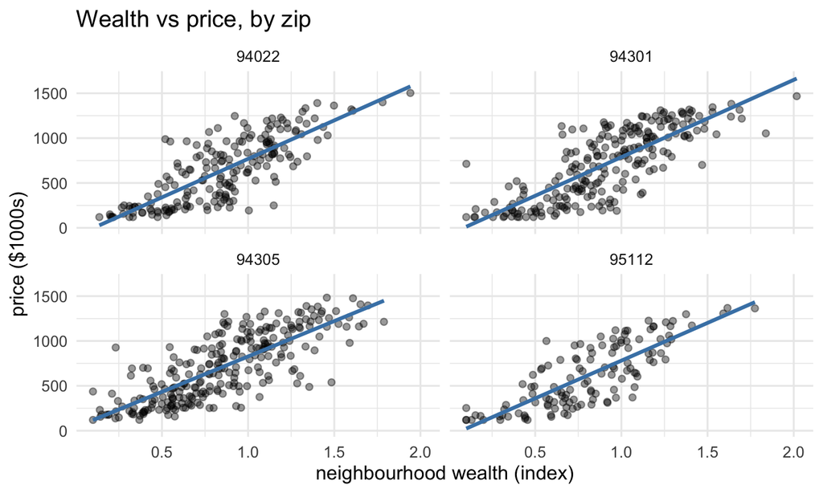

```r
houses %>%
  ggplot(aes(wealth, price)) +
  geom_point(alpha = 0.4) +
  geom_smooth(method = "lm", se = FALSE, colour = "steelblue") +
  facet_wrap(~zip) +
  labs(
    title = "Wealth vs price, by zip",
    x = "neighbourhood wealth (index)", y = "price ($1000s)"
  ) +
  theme_minimal(base_size = 12)
```

## Create Training and Testing Data

We start by scaling the numeric columns in the training set. For `nnet`, we also need to scale $y$ since the `nnet` package is unstable when the output lives on a $10^2$–$10^3$ scale.

```r
index <- sample(seq_len(nrow(houses)), size = floor(0.75 * nrow(houses)))
train <- houses[index, ]
test  <- houses[-index, ]

make_xy <- function(df, scaler = NULL) {
  mm <- model.matrix(price ~ size + beds + zip + wealth, data = df)[, -1]
  if (is.null(scaler)) {
    scaler <- list(
      x_center = colMeans(mm),
      x_scale  = pmax(apply(mm, 2, sd), 1e-8),
      y_center = mean(df$price),
      y_scale  = sd(df$price)
    )
  }
  X <- scale(mm, center = scaler$x_center, scale = scaler$x_scale)
  y_sc <- (df$price - scaler$y_center) / scaler$y_scale
  list(X = X, y = df$price, y_sc = y_sc, scaler = scaler)
}

unscale_y <- function(y_sc, scaler) scaler$y_center + scaler$y_scale * y_sc

tr <- make_xy(train)
te <- make_xy(test, scaler = tr$scaler)
```

We are now ready to run the different types of “regressions”. For each model, we keep the MSE on the testing set to compare in the end.

### 1. Raw Features

This is the usual OLS which we means that we specify $f_\beta(x)=\beta^\top x$ on size, beds, zip dummies, and wealth.

```r
fit_raw <- lm(price ~ size + beds + zip + wealth, data = train)
pred_raw_tr <- predict(fit_raw, newdata = train)
pred_raw_te <- predict(fit_raw, newdata = test)
mse_raw <- c(train = mse(train$price, pred_raw_tr),
             test  = mse(test$price,  pred_raw_te))
coef(fit_raw)
```

```
##  (Intercept)         size         beds     zip94301     zip94305     zip95112
## -261.6230314    0.2630489   51.3892150   -3.5935366   45.3503352    6.5097652
##       wealth
##  199.6762570
```

```r
mse_raw
```

```
##    train     test
## 2212.909 2622.138
```

### 2. Hand-built $\phi$

In the simulated data, we have a a floor on size at $1100$ ft$^2$, and $\mathrm{beds}\times\mathrm{wealth}$. So, we fit an OLS that matches this *specific* behavior:

```r
train_phi <- train %>%
  mutate(
    size_corner = relu(size - 1100),
    beds_wealth = beds * wealth
  )
test_phi <- test %>%
  mutate(
    size_corner = relu(size - 1100),
    beds_wealth = beds * wealth
  )

fit_phi <- lm(
  price ~ size_corner + beds + zip + wealth + beds_wealth,
  data = train_phi
)
pred_phi_tr <- predict(fit_phi, newdata = train_phi)
pred_phi_te <- predict(fit_phi, newdata = test_phi)
mse_phi <- c(train = mse(train$price, pred_phi_tr),
             test  = mse(test$price,  pred_phi_te))
coef(fit_phi)
```

```
## (Intercept) size_corner        beds    zip94301    zip94305    zip95112
##   66.644408    0.281340   26.203743   -3.322533   49.660671   10.872722
##      wealth beds_wealth
##  118.070683   26.133155
```

```r
mse_phi
```

```
##    train     test
## 1378.671 1502.382
```

### 3. Cubic in `size`; Raw in other Features

```r
fit_poly <- lm(price ~ poly(size, 3) + beds + zip + wealth, data = train)
pred_poly_tr <- predict(fit_poly, newdata = train)
pred_poly_te <- predict(fit_poly, newdata = test)
mse_poly <- c(train = mse(train$price, pred_poly_tr),
              test  = mse(test$price,  pred_poly_te))
mse_poly
```

```
##    train     test
## 1547.147 1676.755
```

### 4. One-Hidden-Layer Net

`nnet` fits
$$a=\sigma(W^{[1]}x+b^{[1]}),
\qquad
\hat y=W^{[2]}a+b^{[2]},$$
with a **sigmoid** $\sigma$ (not ReLU) and `linout = TRUE`. `decay` is weight decay. The net sees only the *scaled raw* design, not `size_corner` or interaction `beds_wealth`.

```r
fit_one_nnet <- function(size = 8, decay = 0.01, maxit = 800) {
  nnet(
    x = tr$X, y = tr$y_sc,
    size = size, linout = TRUE, trace = FALSE,
    decay = decay, maxit = maxit, MaxNWts = 5000
  )
}

pick_best <- function(candidates) {
  candidates[[which.min(vapply(candidates, `[[`, numeric(1), "value"))]]
}

set.seed(598)
nn8 <- pick_best(replicate(10, fit_one_nnet(size = 8, decay = 0.001),
                           simplify = FALSE))
pred_nn8_tr <- unscale_y(as.numeric(predict(nn8, tr$X)), tr$scaler)
pred_nn8_te <- unscale_y(as.numeric(predict(nn8, te$X)), tr$scaler)
mse_nn8 <- c(train = mse(train$price, pred_nn8_tr),
             test  = mse(test$price,  pred_nn8_te))

set.seed(5981)
nn16 <- pick_best(replicate(8, fit_one_nnet(size = 16, decay = 0.002),
                            simplify = FALSE))
pred_nn16_tr <- unscale_y(as.numeric(predict(nn16, tr$X)), tr$scaler)
pred_nn16_te <- unscale_y(as.numeric(predict(nn16, te$X)), tr$scaler)
mse_nn16 <- c(train = mse(train$price, pred_nn16_tr),
              test  = mse(test$price,  pred_nn16_te))

set.seed(5982)
nn_wide <- pick_best(replicate(6, fit_one_nnet(size = 24, decay = 1e-5),
                               simplify = FALSE))
pred_wide_tr <- unscale_y(as.numeric(predict(nn_wide, tr$X)), tr$scaler)
pred_wide_te <- unscale_y(as.numeric(predict(nn_wide, te$X)), tr$scaler)
mse_wide <- c(train = mse(train$price, pred_wide_tr),
              test  = mse(test$price,  pred_wide_te))

list(nn8 = mse_nn8, nn16 = mse_nn16, nn_wide = mse_wide)
```

```
## $nn8
##    train     test
## 1246.668 1659.976
##
## $nn16
##    train     test
## 1071.003 1933.109
##
## $nn_wide
##     train      test
##  775.9467 2536.3354
```

## Train and Test MSE

```
## # A tibble: 6 × 5
##   method                                   chapter  train_MSE test_MSE test_RMSE
##   <chr>                                    <chr>        <dbl>    <dbl>     <dbl>
## 1 OLS, hand-built φ (corner + interaction) previou…     1379.    1502.      38.8
## 2 NN, 8 hidden units                       this ch…     1247.    1660.      40.7
## 3 OLS, cubic in size                       previou…     1547.    1677.      40.9
## 4 NN, 16 hidden units                      this ch…     1071.    1933.      44.0
## 5 NN, 24 hidden units, tiny decay          this ch…      776.    2536.      50.4
## 6 OLS, raw features                        previou…     2213.    2622.      51.2
```

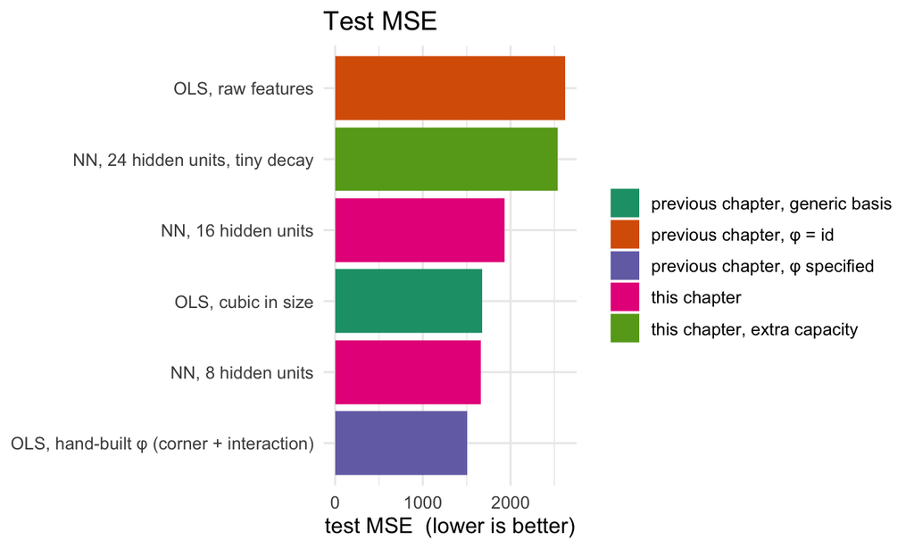

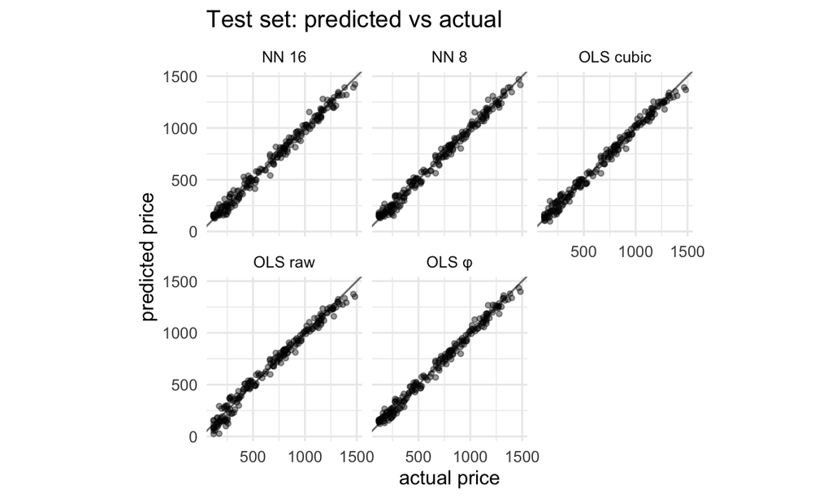

## What raw OLS missed

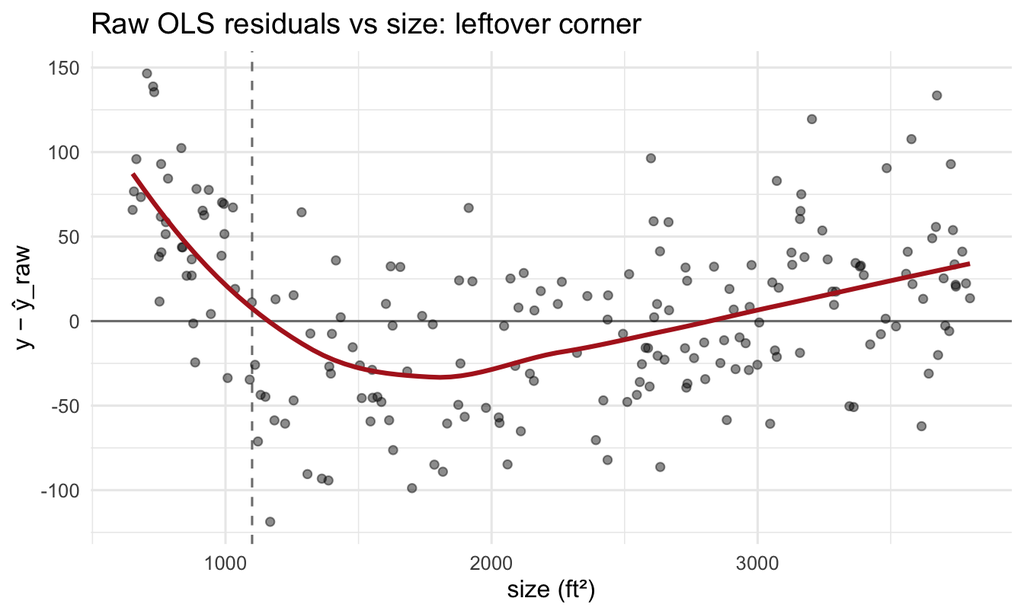

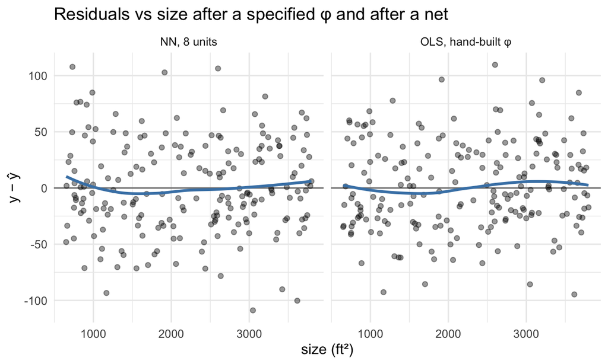

The results we obtain are not surprising. The “hand-built” $\phi$ is the best, since it captures exactly the corner points. Obviously, this is not easy to guess in practice (when one does not know whether even to expect a corner). An experienced statistician might pick it up by looking at the residual plots.

A small net with a little weight decay is quite close to the hand-picked OLS, **without being told the columns** which shows how well the NN learned the shape of $phi$.

This method is followed by a cubic in size which fakes a bend, but misses the interaction. As expected Raw OLS is the worst. One slope cannot be a floor. Also, a wide net with almost no decay is often best on the *training* MSE but it performs worse on test MSE.